# Análise da explicabilidade qualitativa do vinho português

Introdução à Aprendizagem Automática

Nelson Estevão$^{A76434}$

Rui Reis$^{A84930}$

Susana Marques$^{A84167}$

# Introdução & Contextualização

# Metodologia

Ao longo deste trabalho foi utilizada a metodologia CRISP-DM, a qual visa transmitir os diferentes passos associados a um problema de modelação de dados. Os principais aspectos considerados neste estudo foram:

- **Compreensão de negócio** - Perceber como funciona o negócio em questão e de que forma os atributos podem ser utilizados a nosso favor.
- **Compreensão dos dados** - Analisar possíveis relações entre os diferentres atributos, bem como cada um dos atributos de forma geral. Perceber o comportamento dos dados utilizados.
- **Preparação dos Dados** - Ao contrário dos aspectos acima, este passo não pode ser bem definido, pois é avaliado ao longo do desenvolvimento de um modelo especifico. Adequando os atributos ao respectivo modelo, de forma a perceber o que funciona melhor em cada casa.
- **Modelação** - Aqui tentamos utilizar os diferentes modelos ao nosso dispor e avaliar qual é o mais adequado no contexto em que estamos inseridos. Neste estudo abordamos os modelos: Regressão Logística, LDA, QDA, K-Nearest Neighbours.
- **Avaliação** - Para além dos diferentes modelos, é necessário uma boa forma de os avaliar. O *cross validation* é o método de seleção para a avaliação da qualidade do modelo.

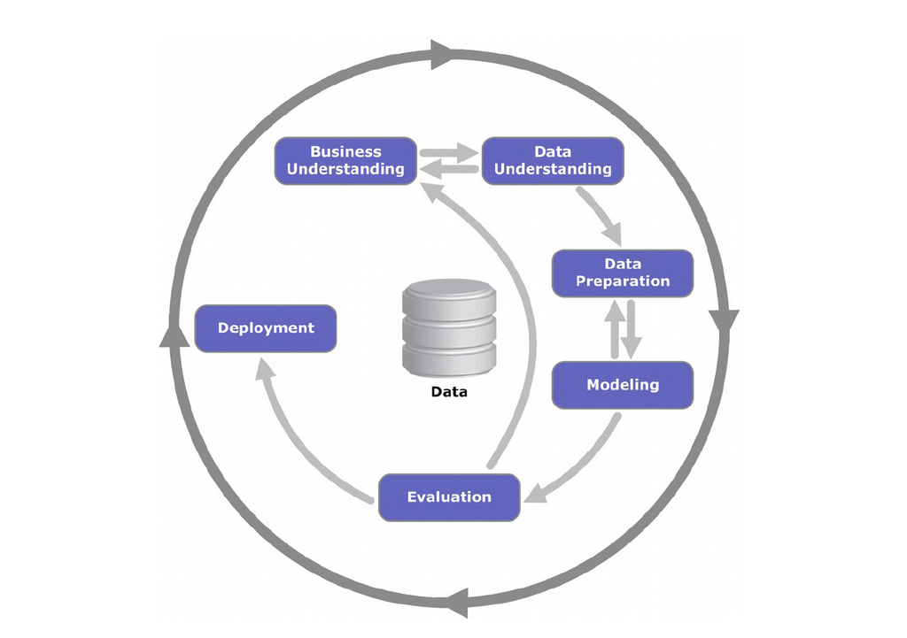

Metodologia CRISP-DM

Claro que, todo este funcionamento é iterativo e, por vezes, pode ser necessário voltar atrás e tomar um conjunto de decisões diferentes que permitam obter um melhor resultado.

# Compreensão de Negócio

O vinho é de importância extrema, a vários níveis, para a sociedade portuguesa. Com isto em mente, e tendo em conta a importância económica, conseguimos ver utilidade na utilização de técnicas de aproveitamento de dados de forma a responder questões fulcrais para a comunidade de vinicultores, de forma a que esta consiga produzir vinhos que melhor se adequam à sociedade e competição de mercado existente.

Para alcançar esse objetivo, utilizamos dois conjuntos de dados, que representam dois tipos de vinhos, branco e tinto. A nossa análise é feita de forma abstrata na maioria dos pontos, focando-nos, quando necessário, na diferença entre os dois tipos. Os *data sets* utilizados possuem ambos um conjunto de 12 atributos, com 4898 amostras para o vinho verde e 1599 para o vinho tinto.

Neste documento, e com o intuito de aderir à metodologia CRISP-DM, o nosso objetivo é o de esclarecer a importância de cada atributo em termos de conhecimento de domínio e tentar inferir informação importante que possamos vir a retirar destes.

## Especificação dos Atributos

Como referido anteriormente, os *data sets* encapsulam um total de 12 atributos, sendo que maioria deles são de uma especificidade técnica fora do nosso conhecimento. Pelo que, uma análise mais aprofundada é devida. De seguida, no formato de `Nome, Tipo : Descrição` apresentamos a nossa análise sobre cada atributo, quando conveniente apresentamos abaixo informação específica adicional. As unidades de cada atributo podem ser verificadas no estudo original de (Cortez et al. 2009).

- `fixed acidity`, numérico: Representa a acidez fixa que é a soma dos ácidos fixos. Tartárico e Málico são os mais importantes. Por princípio, quanto mais elevada for a acidez fixa, mais baixa é a volátil. As bactérias acéticas têm dificuldade em desenvolver-se em meios mais ácidos. (Afonso 2017)
  - **Unidade de Medida**: g(tartaric acid)/dm$^3$.
- `volatile acidity`, numérico: Representa a acidez volátil que é a soma dos ácidos voláteis, que se libertam pela ebulição ou destilação do vinho e traduz o nível de ataque aceto bacteriano ao vinho. Por lei não pode ultrapassar o valor de 1,2 g de ácido acético por litro. (Afonso 2017)
  - **Unidade de Medida**: g(acetic acid)/dm$^3$.
- `citric acid`, numérico: O ácido cítrico é um ácido orgânico fraco, que se pode encontrar nos citrinos. É usado como conservante natural (antioxidante), dando um sabor ácido e refrescante na preparação de alimentos e de bebidas. (Wikipédia 2020)
  - **Unidade de Medida**: g/dm$^3$.
- `residual sugar`, numérico: O açúcar residual refere-se aos açúcares que não foram fermentados no vinho acabado. A quantidade de açúcar residual afeta a doçura do vinho. Na união europeia existe uma correspondência entre o açúcar residual e termos de rotulagem. (Wu 2020)
  - **Unidade de Medida**: g/dm$^3$.
- `chlorides`, numérico: Representa quantidade de sal no vinho, no entanto, concentrações moderadas a grandes de cloretos podem dar ao vinho um sabor salgado que pode desmotivar o consumidor. Quando os níveis desses elementos excedem certos limites, a comercialização e venda do vinho pode não ser permitida em alguns países. (Coli et al. 2015)
  - **Unidade de Medida**: g(sodium chloride)/dm$^3$.
- `free sulfur dioxide`, numérico: Representa a quantidade de dióxido de enxofre não reagido no vinho, por essa razão é capaz de garantir uma ação antioxidante. (BRI, n.d.)
  - **Unidade de Medida**: mg/dm$^3$.
- `total sulfur dioxide`, numérico: Representa a quantidade de dióxido de enxofre livre mais a que está associada a outros químicos no vinho. Esta quantidade é regulada, por exemplo, pelos Estados Unidos que limita a concentração total de dióxido de enxofre a 350 mg/L. Na EU, o limite legal é de 150mg/L para vinho tinto e 200mg/L para vinho branco. (Moroney 2018; BRI, n.d.)
  - **Unidade de Medida**: mg/dm$^3$.
- `density`, numérico: Quociente entre a massa e volume do vinho.
  - **Unidade de Medida**: g/cm$^3$.
- `pH`, numérico: A importância da acidez para o vinho não pode ser subestimada, pois contribui com frescor, atua como um agente conservante e ajuda, notavelmente, com a estabilidade microbiana. O pH do vinho tende a estar entre 2 e 4. (Charest 2019)
  - **Domínio**: $x \in [0,14]$.
- `sulphates`, numérico: Aditivo do vinho, age como um anti-microbiano e anti-oxidante. No entanto, não foi detetada informação relevante sobre este atributo.
  - **Unidade de Medida**: g(potassium sulphate)/dm$^3$.
- `alcohol`, numérico: Percentagem de total de álcool no vinho.
  - **Unidade de Medida**: vol.%.
  - **Domínio**: $x \in [0,100]$.
- `quality`, nominal: Classe objetivo, varia de 0 a 10 e representa a qualidade do vinho.
  - **Domínio**: $x \in \{0,1,2,\cdots,10\}$.

## Percepções Valiosas

A partir das especificações acima, conseguimos encontrar as seguintes percepções valiosas sobre o significado dos atributos na lógica de negócio subjacente.

- Quanto mais elevada for a `fixed acidity`, menor é a `volatile acidity`.
- Bactérias acéticas têm mais dificuldade em desenvolver-se em meios ácidos, `pH < 7`.
- Em Portugal, a `volatile acidity`, por lei, não pode ultrapassar o valor de 1,2 g de ácido acético por litro.
- `citric acid` representa um conservante natural, dando um sabor ácido e refrescante.
- A quantidade de `residual sugar` afeta a doçura do vinho de forma diretamente proporcional.
- `chlorides` elevados podem dar um sabor salgado ao vinho, o que desmotiva o consumidor.
- `pH` do vinho tende a estar entre 2 e 4.

# Compreensão dos Dados

A compreensão dos dados é tanto ou mais importante que compreender o negócio em questão. A partir dos dados podemos extrair relações, questões de interesse, bem como desenvolver modelos de inferência coerentes. Esta secção destina-se a agregar a análise dos nossos dados em duas componentes. Passo a passo, abordamos os atributos mais importantes e de que forma, para ambos os data sets considerados, funciona a dinâmica dos mesmos.

## Acidez fixa e volátil

Como aferido pelo conhecimento de domínio, somos endereçados para o facto de que tende a existir uma forte correlação negativa, ou inversamente proporcional, entre a acidez fixa e volátil. Numa primeira tentativa, podemos obter as seguintes informações sobre os dados.

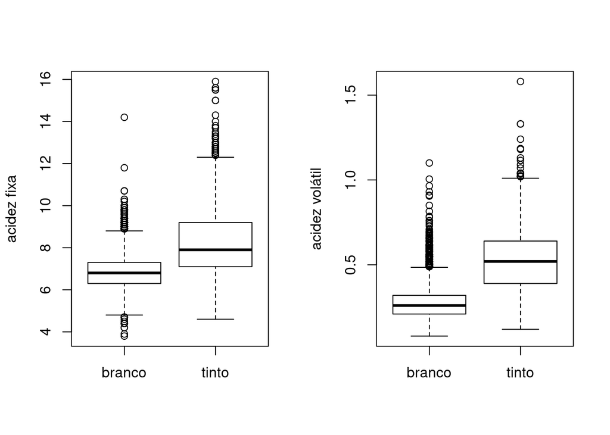

```r
par(mfrow=c(1,2))
boxplot(white_wine$fixed.acidity, red_wine$fixed.acidity, names=c("branco","tinto"),ylab=c("acidez fixa"))
boxplot(white_wine$volatile.acidity, red_wine$volatile.acidity, names=c("branco","tinto"),ylab=c("acidez volátil"))
```

```r
corrlat <- cor(white_wine[c("fixed.acidity","volatile.acidity")])
knitr::kable(corrlat, caption = "Correlação entre atributos acídicos, para o vinho branco", align="cr")
```

Correlação entre atributos acídicos, para o vinho branco

|  | fixed.acidity | volatile.acidity |
| --- | --- | --- |
| fixed.acidity | 1.0000000 | -0.0226973 |
| volatile.acidity | -0.0226973 | 1.0000000 |

Pela correlação não existe indícios que exista uma relação negativa entre aqueles atributos, no caso do vinho branco. Ao tentarmos visualizar a relação dos dois atributos na forma de um gráfico, obtemos o seguinte resultado.

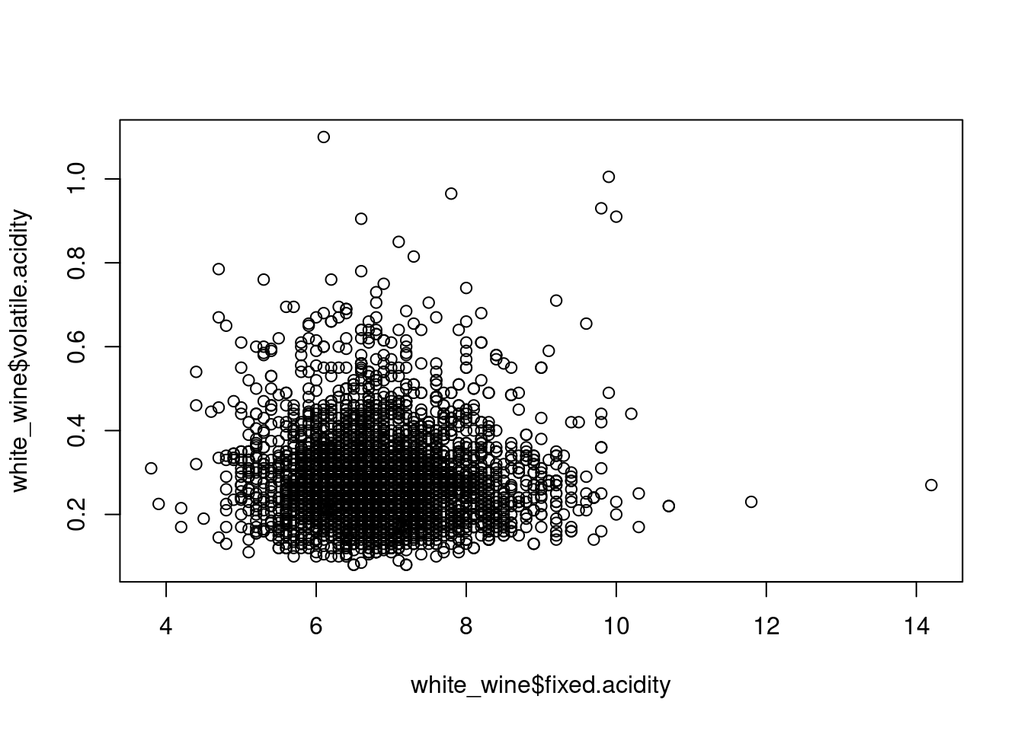

```r
plot(white_wine$fixed.acidity, white_wine$volatile.acidity)
```

Facilmente verificamos que, apesar de haver uma grande concentração de pontos no gráfico, estes não definem nenhuma forma especifica. O que só nos confirma que o conhecimento que foi obtido pelo conhecimento de domínio não se verifica de forma significativa nos dados. Entre muitos fatores, isto pode-se dever ao tipo de *sampling* do vinho que foi utilizado. Se forem considerados só vinhos de uma determinada região, é evidente que podem existir caraterísticas mais especificas que depois não se verificam na população global.

## Cloretos

Apesar de não ser tão evidente, conseguimos perceber, pela figura abaixo, que à medida que o sal no vinho aumenta, então a avaliação da qualidade desse vinho tende a ser menor, para ambos os tipos.

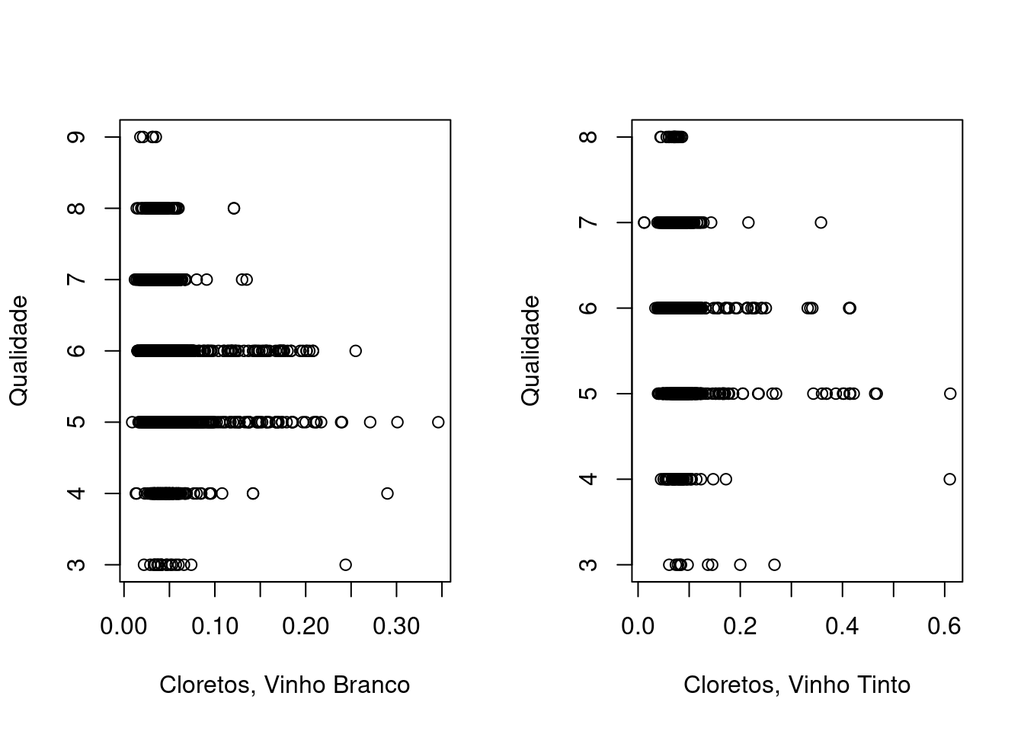

```r
par(mfrow=c(1,2))
plot(white_wine$chlorides, white_wine$quality, xlab="Cloretos, Vinho Branco", ylab="Qualidade")
plot(red_wine$chlorides, red_wine$quality, xlab="Cloretos, Vinho Tinto", ylab="Qualidade")
```

## Dióxido de Enxofre Livre e Total

A relação entre os diferentes tipos de dióxido de enxofre parece ser intuitiva e há indícios para a existência de uma relação de linearlidade entre os dois atributos.

### Vinho Tinto

Começemos por analisar o caso do vinho tinto, como podemos verificar na figura seguinte. Podemos verificar a existência de uma relação parecida a linear, no entanto, com um formato afunilado. Este formato afunilado pode ser um sinal de heteroscedasticidade, caso onde se verifica variâncias não constantes nos erros. Este problema poder vir a ser uma fonte medidas de erro com elevado valor no futuro, especialmente em modelos que partem do pressuposto de um variância constante, como acontece na regressão linear.

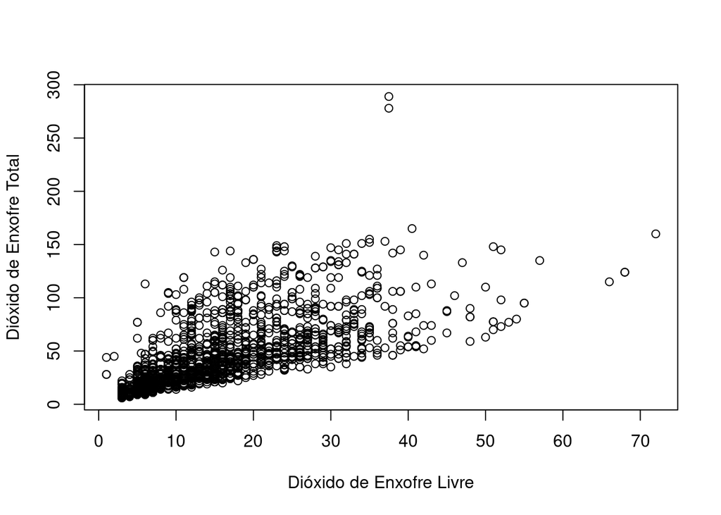

```r
plot(red_wine$free.sulfur.dioxide, red_wine$total.sulfur.dioxide, xlab="Dióxido de Enxofre Livre", ylab="Dióxido de Enxofre Total")
```

Se tentarmos fazer uma simples regressão linear, rapidamente percebemos que o modelo possui alguma dificuldade em se adaptar a dados com variâncias não constantes nos erros. Como tal, a reta resultante não aparenta espelhar bem a relação com os dados.

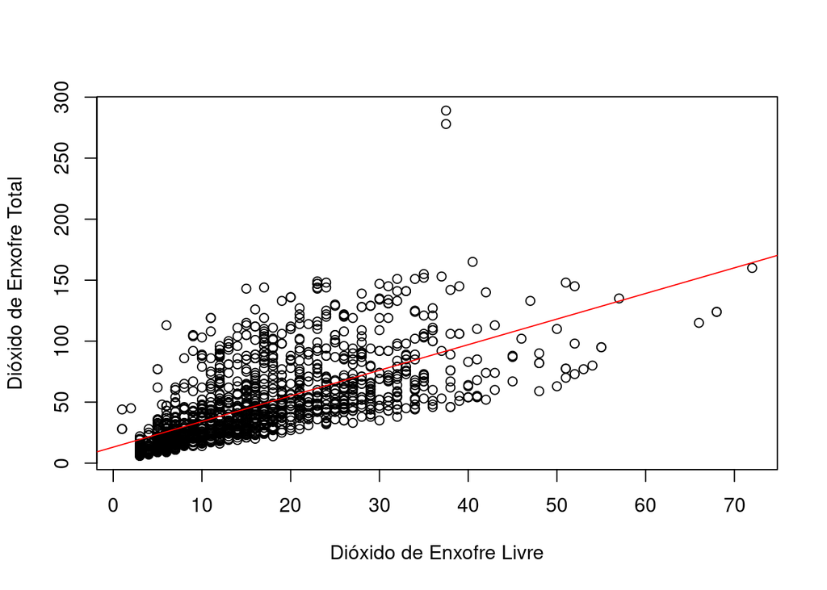

```r
plot(red_wine$free.sulfur.dioxide, red_wine$total.sulfur.dioxide, xlab="Dióxido de Enxofre Livre", ylab="Dióxido de Enxofre Total")
model1 <- lm(total.sulfur.dioxide ~ free.sulfur.dioxide, data = red_wine)
abline(model1, col="red")
```

O modelo acima permite-nos calcular um RSE de:

```r
sqrt(mean(model1$residuals^2))
```

```
## [1] 24.48161
```

Uma possível solução corresponde a mudar a escala utilizada, normalmente para logarítmica ou raiz quadrada. No nosso caso, escolhemos raiz quadrada por produzir os melhores resultados. Como podemos ver abaixo, a reta resultante da regressão linear parece acompanhar de forma mais adequada os dados. Deixou de se verificar a existência de uma forma afunilada.

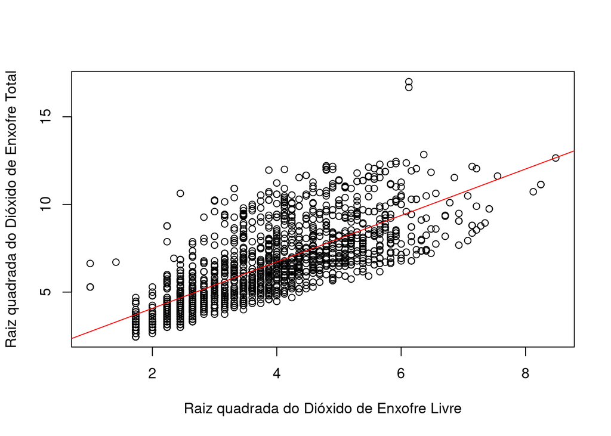

```r
plot(sqrt(red_wine$free.sulfur.dioxide), sqrt(red_wine$total.sulfur.dioxide), xlab="Raiz quadrada do Dióxido de Enxofre Livre", ylab="Raiz quadrada do Dióxido de Enxofre Total")
model2 <- lm(sqrt(total.sulfur.dioxide) ~ sqrt(free.sulfur.dioxide), data =red_wine)
abline(model2, col="red")
```

O modelo acima permite-nos calcular um RSE de:

```r
sqrt(mean(model2$residuals^2))
```

```
## [1] 1.517755
```

O que representa uma melhoria significativa aos resultados anteriormente obtidos, sem ter a consideração a existência de heteroscedasticidade.

### Vinho Branco

Para o conjunto do vinho branco conseguimos denotar uma figura também afunilada, evidenciando o mesmo tipo de problemas. Podemos também detetar a existência de um *high leverage point* à direita. Idealmente, deveriamos ter em consideração o impacto deste tipo de pontos. Porém, como estamos a fazer uma análise apenas à heteroscedasticidade, achamos desnecessário ter em consideração todas as componentes.

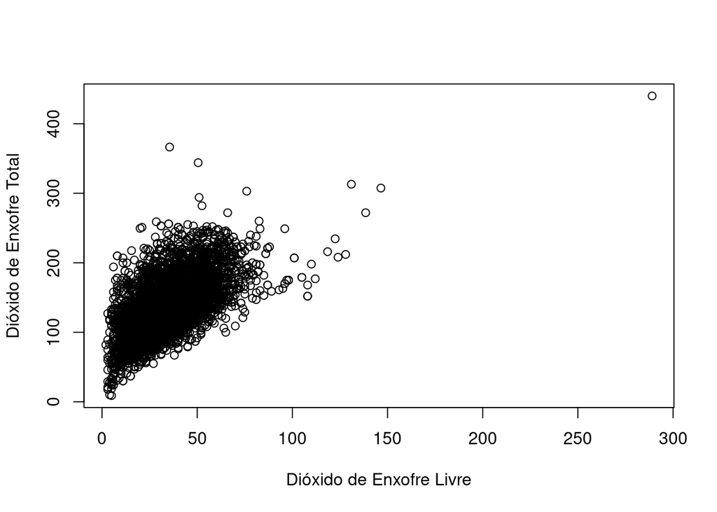

```r
plot(white_wine$free.sulfur.dioxide, white_wine$total.sulfur.dioxide, xlab="Dióxido de Enxofre Livre", ylab="Dióxido de Enxofre Total")
```

Ao tentarmos utilizar regressão linear, conseguimos perceber que o linha gerada acompanha muito mal os dados.

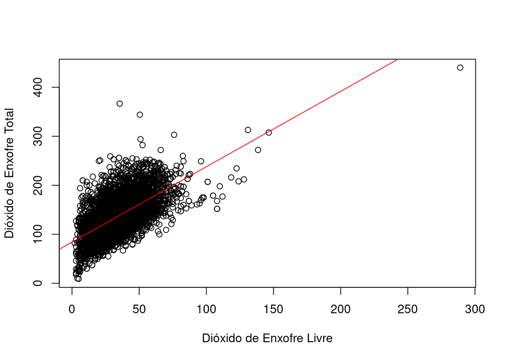

```r
plot(white_wine$free.sulfur.dioxide, white_wine$total.sulfur.dioxide, xlab="Dióxido de Enxofre Livre", ylab="Dióxido de Enxofre Total")
model1 <- lm(total.sulfur.dioxide ~ free.sulfur.dioxide, data = white_wine)
abline(model1, col="red")
```

O modelo acima permite-nos calcular um RSE de:

```r
sqrt(mean(model1$residuals^2))
```

```
## [1] 33.49084
```

De igual forma ao caso do vinho tinto, podemos alterar a escala dos nosso atributos para evitar o problema das variâncias não-constantes.

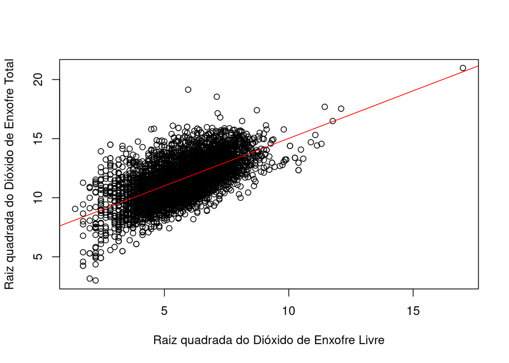

```r
plot(sqrt(white_wine$free.sulfur.dioxide), sqrt(white_wine$total.sulfur.dioxide), xlab="Raiz quadrada do Dióxido de Enxofre Livre", ylab="Raiz quadrada do Dióxido de Enxofre Total")
model2 <- lm(sqrt(total.sulfur.dioxide) ~ sqrt(free.sulfur.dioxide), data =white_wine)
abline(model2, col="red")
```

O modelo acima permite-nos calcular um RSE de:

```r
sqrt(mean(model2$residuals^2))
```

```
## [1] 1.430711
```

A melhoria é extremamente significativa, e facilmente conseguimos perceber que, partindo de uma situação com um problema de heteroscedasticidade tão grave, conseguimos obter uma melhoria de performance cerca de 20 vezes melhor. Com este informação, conseguimos confirmar a existência e a solução para o problema de heteroscedasticidade neste par de atributos. O que podera vir a ser relevante em modelos especificos.

## Qualidade

Perceber a distribuição da classe objetivo é igualmente importante a compreender os outros atributos. Quando enfrentados com a variável de qualidade somos atingidos pelos seguinte gráficos.

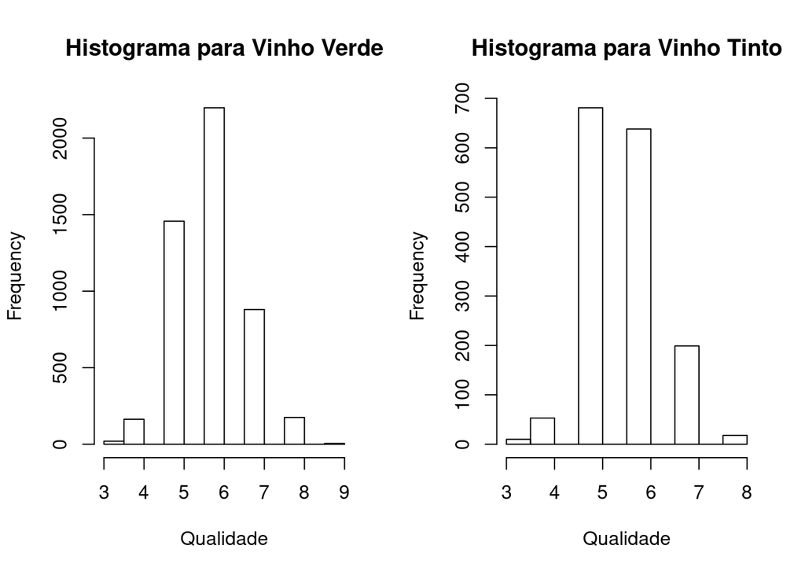

```r
par(mfrow=c(1,2))
hist(white_wine$quality, main="Histograma para Vinho Verde", xlab="Qualidade")
hist(red_wine$quality, main="Histograma para Vinho Tinto", xlab="Qualidade")
```

Que nos permitem perceber que existe uma péssima representatividade da classe objetivo, tendo em conta que a cardinalidade desta é de 10. Existem até qualidade que nunca se verificam. Assume-se que, por os dados terem sido recolhidos de forma sensorial, recorrendo a júris, existe um bias implícito associado. É aceitável considerar que os júris tendem a preferir não dar classificações extrema, nem muito boas, nem muito más, o que se verifica na prática, em ambos os data sets, pois os valores mais frequentes são o 5 e 6. Isto implica outro problema, nomeadamente, a má separação inter-classe devido a se tratar de um problema que depende da subjetividade do humano. É razoável assumir que 2 júris podem dar classificações completamente apostas a um mesmo vinho que, do ponto de vista laboratorial, seria considerado ótimo.

Posto isto, conseguimos prever *a priori* que qualquer modelo desenvolvimento deverá possuir uma *accuracy* pequena, devido, principalmente, ao problema da má separação entre as classes.

## Análise Genérica

Com o intuito de tentar abordar atributos que achamos que não foram devidamente abordados, tentamos ilustrá-los utilizando a seguinte *scatter matrix*. Da qual denotamos os seguintes pontos.

- Parece existir uma forte relação positiva entre o açúcar residual e a densidade do vinho.
- Parece existir uma relação entre o sal e a densidade.
- Apesar de não tão óbvia, parece também existir uma relação entre o ácido cítrico e o sal.

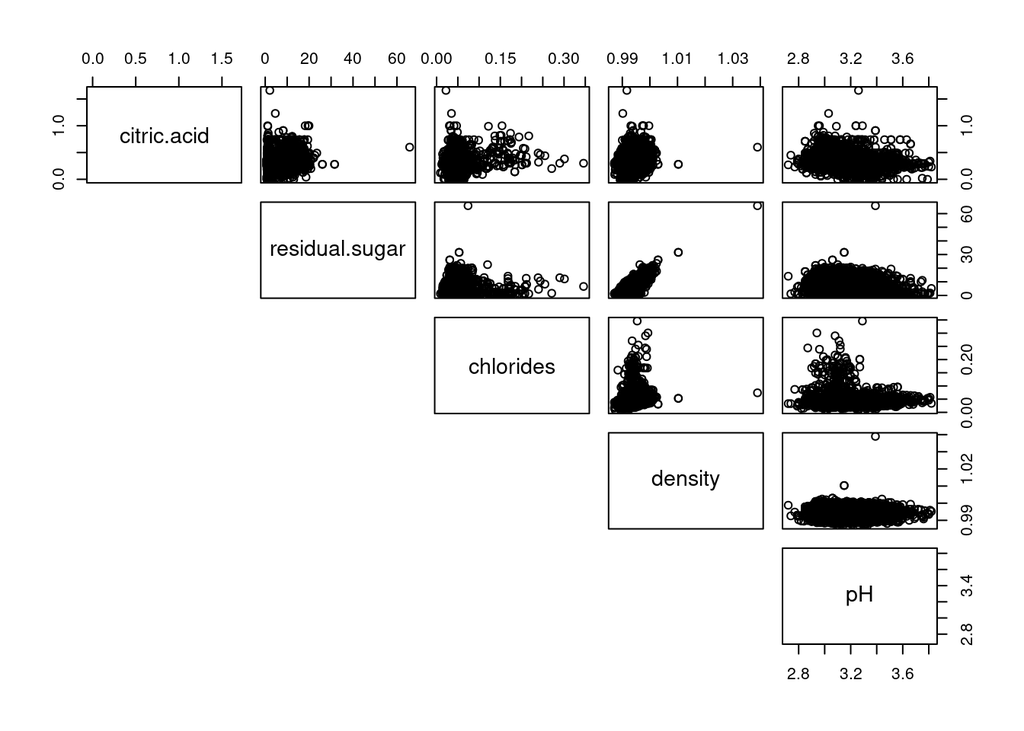

```r
pairs(white_wine[,-c(1,2,6,7,10,11,12)], lower.panel = NULL)
```

De forma a introduzir um nível mais técnico, utilizamos uma correlação para tentar determinar se estas relações existem de facto.

```r
corr_white <- cor(white_wine[,-c(1,2,6,7,10,11,12)])
knitr::kable(corr_white, caption = "Correlação entre atributos de interesse, para o vinho branco", align="cr")
```

Correlação entre atributos de interesse, para o vinho branco

|  | citric.acid | residual.sugar | chlorides | density | pH |
| --- | --- | --- | --- | --- | --- |
| citric.acid | 1.0000000 | 0.0942116 | 0.1143644 | 0.1495026 | -0.1637482 |
| residual.sugar | 0.0942116 | 1.0000000 | 0.0886845 | 0.8389665 | -0.1941335 |
| chlorides | 0.1143644 | 0.0886845 | 1.0000000 | 0.2572113 | -0.0904395 |
| density | 0.1495026 | 0.8389665 | 0.2572113 | 1.0000000 | -0.0935915 |
| pH | -0.1637482 | -0.1941335 | -0.0904395 | -0.0935915 | 1.0000000 |

Partindo da tabela acima, conseguimos evidenciar que a única relação que verdadeiramente se evidencia como forte correlação positiva é entre o açúcar residual e a densidade. Poderá vir a ser interessante remover um destes atributos na tentiva de perceber como os modelos respondem.

## Questões Relevantes

Do conjunto de análises efetuadas acima, surgem um conjunto de questões de interesse, que ilustram o foco do nosso estudo em secções adiante.

- **Questão 1**: Quais atributos devem ser considerados para melhorar a qualidade de um vinho?
- **Questão 2**: Como lidar com a má separação de classes inerente a avaliações sensoriais?
- **Questão 3**: Qual o impacto de atributos não significativos no mercado do vinho?

# Conclusões

# Linear Discriminant Analysis

## Descrição

## Funcionamento

## Casos de Estudo

### Vinho Branco

## Conclusões

# Quadratic Discriminant Analysis

## Descrição

## Funcionamento

## Casos de Estudo

### Vinho Branco

## Conclusões

# Referências

Afonso, João. 2017. “Acidez, álcool E Tanino.” https://grandesescolhas.com/acidez/.

BRI, Campden. n.d. “Wine Analysis.” https://www.campdenbri.co.uk/services/wine-analysis.php#sulphur-dioxide.

Charest, Rémy. 2019. “How Winemakers Analyze pH and Its Impact on Wine.” https://daily.sevenfifty.com/how-winemakers-analyze-ph-and-its-impact-on-wine/.

Coli, Marina Sonegheti, Angelo Gil Pezzini Rangel, Elizangela Silva Souza, Margareth Ferraro Oliveira, and Ana Cristina Nascimento Chiaradia. 2015. “Chloride concentration in red wines: influence of terroir and grape type.” *Food Science and Technology* 35 (March): 95–99. http://www.scielo.br/scielo.php?script=sci_arttext&pid=S0101-20612015000100095&nrm=iso.

Cortez, P., A. Cerdeira, Fernando Almeida, T. Matos, and J. Reis. 2009. “Modeling Wine Preferences by Data Mining from Physicochemical Properties.” *Decis. Support Syst.* 47: 547–53.

Moroney, Maureen. 2018. “Total Sulfur Dioxide - Why It Matters, Too!” https://www.extension.iastate.edu/wine/total-sulfur-dioxide-why-it-matters-too.

Wikipédia. 2020. “Ácido Cítrico.” https://pt.wikipedia.org/wiki/Ácido_cítrico.

Wu, Sylvia. 2020. “What Is Residual Sugar in Wine? – Ask Decanter.” https://www.decanter.com/learn/residual-sugar-46007/.